# 06 — Age and Cohorts

# 7. Mundlak Decomposition

Separates the *between-player* effect of distance (do longer hitters systematically differ?) from the *within-player* effect (does a player’s own distance change matter, holding their identity fixed?), alongside age.

```r
df_mundlak <- df_3plus %>% mutate(age_c2 = (age - mean(age))^2)

fit_mundlak <- lm(distance ~ year + dist_player_mean + dist_within + age + age_c2, data = df_mundlak)

tidy(fit_mundlak) %>% print()
```

```
## # A tibble: 6 x 5
##   term               estimate std.error statistic p.value
##   <chr>                 <dbl>     <dbl>     <dbl>   <dbl>
## 1 (Intercept)       2.55 e-11  1.02e-11   2.49e 0  0.0126
## 2 year             -1.21 e-14  5.31e-15  -2.28e 0  0.0227
## 3 dist_player_mean  1.00 e+ 0  4.00e-15   2.50e14  0
## 4 dist_within       1.000e+ 0  7.71e-15   1.30e14  0
## 5 age              -1.29 e-14  5.15e-15  -2.50e 0  0.0124
## 6 age_c2            1.42 e-15  6.10e-16   2.32e 0  0.0203
```

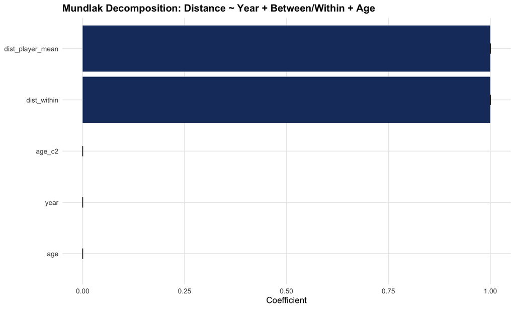

```r
mundlak_coefs <- tidy(fit_mundlak) %>% filter(term != "(Intercept)")

p_mundlak <- ggplot(mundlak_coefs, aes(estimate, fct_reorder(term, estimate))) +
  geom_col(fill = COL_PRIMARY) +
  geom_errorbarh(aes(xmin = estimate - 1.96 * std.error, xmax = estimate + 1.96 * std.error), height = 0.2) +
  labs(title = "Mundlak Decomposition: Distance ~ Year + Between/Within + Age", x = "Coefficient", y = NULL) +
  THEME_BASE

p_mundlak
```

# 8. Age Groups: Composition and Relative Standing Over Time

```r
df_main <- df_main %>%
  mutate(age_group = case_when(
    age < 30 ~ "Under 30",
    age < 35 ~ "30-34",
    age < 40 ~ "35-39",
    TRUE     ~ "40+"
  ) %>% factor(levels = c("Under 30", "30-34", "35-39", "40+")))
```

## 8.1 Compositional shift

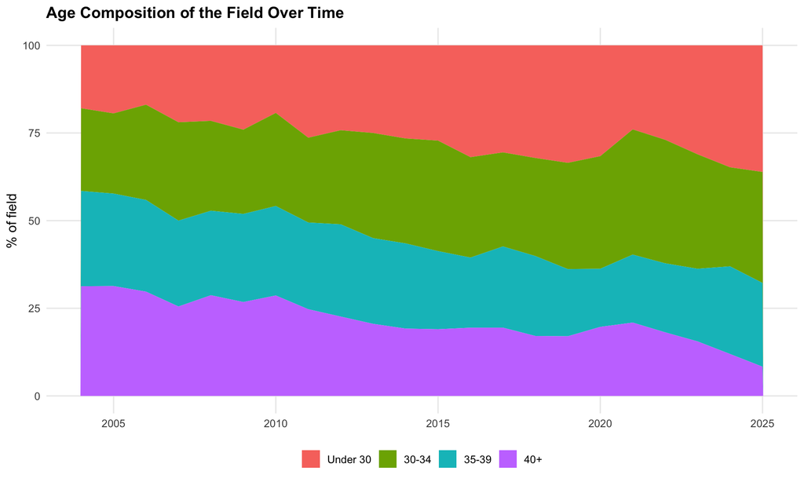

```r
age_comp <- df_main %>%
  count(year, age_group) %>%
  group_by(year) %>%
  mutate(pct = 100 * n / sum(n)) %>%
  ungroup()

p_age_comp <- ggplot(age_comp, aes(year, pct, fill = age_group)) +
  geom_area(position = "stack") +
  labs(title = "Age Composition of the Field Over Time", x = NULL, y = "% of field", fill = NULL) +
  THEME_BASE

p_age_comp
```

```r
share40_2004 <- age_comp %>% filter(year == min(year), age_group == "40+") %>% pull(pct)
share40_2025 <- age_comp %>% filter(year == max(year), age_group == "40+") %>% pull(pct)
```

**Finding:** the 40+ share of the field collapsed from 31.3% (2004) to 8.3% (2025) — a striking, direct answer to “are older players being pushed off tour”: yes, dramatically so.

## 8.2 Relative standing by age group over time

Not just absolute values — is each age group pulling ahead of or falling behind *the rest of the field that same year*?

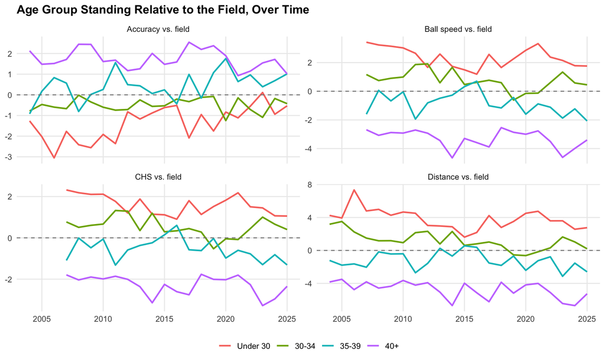

```r
relative_by_group <- bind_rows(
  df_main %>% group_by(year, age_group) %>% summarise(value = mean(dist_vs_field), .groups = "drop") %>% mutate(metric = "Distance vs. field"),
  df_main %>% filter(year >= SPEED_ERA_START) %>% group_by(year, age_group) %>% summarise(value = mean(speed_vs_field), .groups = "drop") %>% mutate(metric = "Ball speed vs. field"),
  df_main %>% filter(year >= SPEED_ERA_START) %>% group_by(year, age_group) %>% summarise(value = mean(chs_vs_field), .groups = "drop") %>% mutate(metric = "CHS vs. field"),
  df_main %>% group_by(year, age_group) %>% summarise(value = mean(acc_vs_field), .groups = "drop") %>% mutate(metric = "Accuracy vs. field")
)

p_relative <- ggplot(relative_by_group, aes(year, value, color = age_group)) +
  geom_line(linewidth = 0.9) +
  geom_hline(yintercept = 0, linetype = "dashed", color = "grey50") +
  facet_wrap(~metric, scales = "free_y") +
  labs(title = "Age Group Standing Relative to the Field, Over Time", x = NULL, y = NULL, color = NULL) +
  THEME_BASE

p_relative
```

```r
dist_gap <- relative_by_group %>% filter(metric == "Distance vs. field", age_group %in% c("Under 30", "40+")) %>%
  pivot_wider(id_cols = year, names_from = age_group, values_from = value) %>%
  mutate(gap = `Under 30` - `40+`)

gap_2004 <- dist_gap %>% filter(year == min(year)) %>% pull(gap)
gap_2025 <- dist_gap %>% filter(year == max(year)) %>% pull(gap)
gap_trend <- tidy(lm(gap ~ year, data = dist_gap)) %>% filter(term == "year")
```

# 9. Individual Trajectories: Prime (30-34) vs. 40+

**This section describes a survivor population, not a general aging claim.** Only players observed both in a “prime” band (age 30-34) and later at 40+ are included — by construction, everyone here already stuck around long enough to reach 40+ on tour. The question this section answers is “what does the relative standing of tour survivors look like at 40+ compared to their own prime,” not “what happens to golfers in general as they age” (an earlier, cruder comparison — median individual age-slope for “ever reached 40+” vs. everyone else — was tested and found confounded by career length, not used here).

```r
compute_prime_vs_40 <- function(metric_col, speed_era_only = FALSE) {
  d <- df_main %>%
    filter(age >= 30, age <= 34 | age >= 40) %>%
    mutate(band = if_else(age <= 34, "prime", "b40"))
  if (speed_era_only) d <- d %>% filter(year >= SPEED_ERA_START)

  d %>%
    group_by(player_name, band) %>%
    summarise(m = mean(.data[[metric_col]], na.rm = TRUE), .groups = "drop") %>%
    pivot_wider(names_from = band, values_from = m) %>%
    filter(!is.na(prime), !is.na(b40)) %>%
    mutate(change = b40 - prime, metric = metric_col)
}

prime_vs_40_all <- bind_rows(
  compute_prime_vs_40("dist_vs_field"),
  compute_prime_vs_40("sg_ott"),
  compute_prime_vs_40("speed_vs_field", speed_era_only = TRUE),
  compute_prime_vs_40("chs_vs_field", speed_era_only = TRUE)
)

metric_labels <- c(
  dist_vs_field = "Distance vs. field (yds)", sg_ott = "SG_OTT",
  speed_vs_field = "Ball speed vs. field (mph)", chs_vs_field = "CHS vs. field (mph)"
)

summary_table <- prime_vs_40_all %>%
  group_by(metric) %>%
  summarise(n = n(), median_change = median(change), pct_maintained = 100 * mean(change >= 0), .groups = "drop")

summary_table %>% print()
```

```
## # A tibble: 4 x 4
##   metric             n median_change pct_maintained
##   <chr>          <int>         <dbl>          <dbl>
## 1 chs_vs_field      76        -3.82            5.26
## 2 dist_vs_field     98        -7.67            6.12
## 3 sg_ott            98        -0.255          19.4
## 4 speed_vs_field    76        -5.31            3.95
```

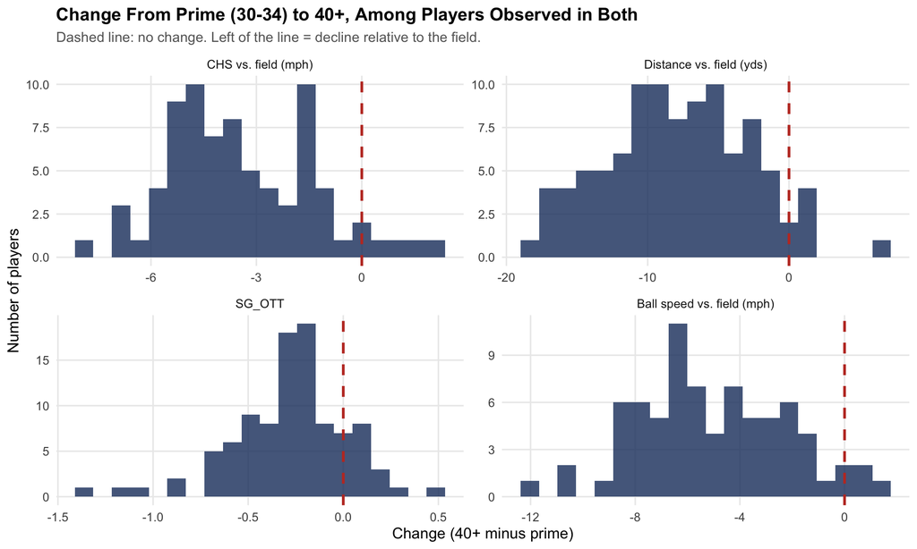

```r
p_prime_vs_40 <- ggplot(prime_vs_40_all, aes(change)) +
  geom_histogram(bins = 20, fill = COL_PRIMARY, alpha = 0.8) +
  geom_vline(xintercept = 0, linetype = "dashed", color = COL_ACCENT, linewidth = 1) +
  facet_wrap(~metric, scales = "free", labeller = as_labeller(metric_labels)) +
  labs(
    title    = "Change From Prime (30-34) to 40+, Among Players Observed in Both",
    subtitle = "Dashed line: no change. Left of the line = decline relative to the field.",
    x = "Change (40+ minus prime)", y = "Number of players"
  ) +
  THEME_BASE

p_prime_vs_40
```

**Finding:** even among players who stuck around long enough to be observed at 40+, the large majority show real relative decline from their own prime — only 6.1% maintained or improved distance-vs-field, 3.9% for ball speed. **SG_OTT holds up noticeably better** (19.4% maintained or improved) than the raw physical metrics — since SG_OTT captures the whole tee-shot outcome, not just raw power, this suggests some players partially offset physical decline with course management or shot-shaping, even when their underlying speed and distance numbers don’t hold up.

# 10. Summary